# Problems-003

### 1) Do we have staples?

Given a list of inventory items and a specific item, write a function that will either print "We have `_` in stock!" or "We are out of `_`" for that item.

Here is a list of inventory:

```
inventory = ['pens', 'paper', 'staples', 'paperclips', 'tape', 'crayons', 'highlighters']
```

##### Example output:

```
>>> do_we_have('staples')
We have staples in stock!
>>> do_we_have('paper')
We have paper in stock!
>>> do_we_have('pencils')
We are out of pencils
```

##### Hints:

You can use the "`in`" operator to check if an item is in a list:

```
>>> 0 in [1, 2, 3]
False
>>> 1 in [1, 2, 3]
True
```

### 2) Array puzzle

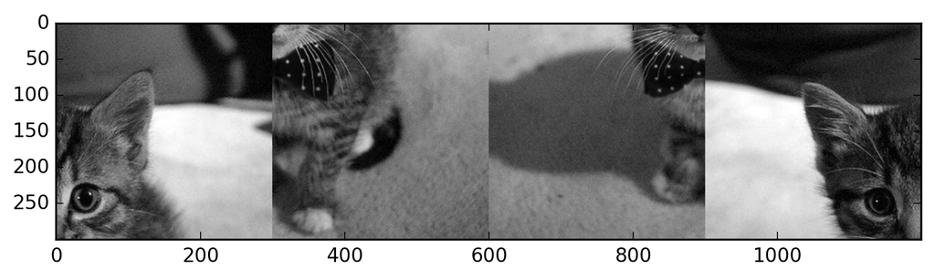

```python
%pylab inline

x = np.mean(imread("data/puzzle.png"), axis=-1)
imshow(x, cmap=cm.gray)
```

For this exercise please download the following image `"puzzle.png"`. Note that the file `"puzzle.png"` would need to be in the same folder as the notebook you are working in (named `"[…].ipynb"`, where `[…]` is the title you put at the top of the notebook). If you put the file `"puzzle.png"` in a folder called `"data"`, as I did, you would need to refer to it as `"data/puzzle.png"`.

This image contains 4 sections of 300 x 300 pixels which I cut out of a 600 by 600 pixel image. You can load the image as an array of pixel values by the following command:

```
x = np.mean(imread("puzzle.png"), axis=-1)
```

The array `x` is now a 300 by 1200 pixel array. You can and should test that by running `x.shape`. You can and should also plot the image with

```
imshow(x, cmap=cm.gray)
```

Where `x` is the array that you would like to turn into an image and `cmap=cm.gray` tells the `imshow` function to interpret the image as a gray scale image. If you leave out the second argument, `imshow` will plot the image on a scale from **red** to **blue** instead of **white** to **black**. Try it out!

Your job is to solve the puzzle by turning the 300 by 1200 image `"puzzle.png"` into a 600 by 600 image `"solution.png"`such that the poor chopped up animal is whole again.

#### Hints:

You need to define at least one new array for the solution image (you can use more helper arrays if you want). You can use the function `np.full()` to create an array `y` of shape `(600,600)` which is filled with any value, e.g. `0`.

Once you solved the puzzle you can save your array `y` as an image with the name `"solution.png"` with the following command:

```
imsave("solution.png", y, cmap=cm.gray)
```

##### Hint 2:

You can also assign to pieces of arrays:

```
>>> big_array = array([1,2,3,4,5,6,7,8,9,10])
>>> piece = array([100, 200])
>>> big_array[:2] = piece
>>> print(big_array)
[100 200   3   4   5   6   7   8   9  10]
```

### 3) Fun with names

Write a function that takes in a person's name, and does one of three things:

1. If the name is less than 5 characters long, it prints out "Hello `_`! Is that your full name?"
2. If the name is between 5 and 8 characters long (inclusive), it prints out "Hello `_`! That's a lovely name!"
3. If the name is more than 8 characters long, it prints out "Hello `_`! Can I call you `[X]`?" Where `[X]` is the first three characters of the person's name.

##### Example output:

```
>>> greeter("Katy")
```

```
Hello Katy! Is that your full name?
```

```
>>> greeter("Manuel")
```

```
Hello Manuel! That's a lovely name!
```

```
>>> greeter("Wendell")
```

```
Hello Wendell! That's a lovely name!
```

```
>>> greeter("Wendell Smith")
```

```
Hello Wendell Smith! Can I call you Wen?
```

```
>>> greeter("Katy Krueger")
```

```
Hello Katy Krueger! Can I call you Kat?
```

##### Hints:

If you get stuck, you may want to do an internet search for "python string concatenation" or "python if statement".